# HW6

Jaein Shin

5/27/2022

```r
# install.packages("glmnet")
# install.packages("janitor")
# install.packages("ranger")
library(tidymodels)
library(tidyverse)
library(rlang)
library(knitr)
library(discrim)
library(klaR)
library(glmnet)
library("janitor")
```

```r
library(corrplot)
library(rpart.plot)
library(ranger)
library(vip)
tidymodels_prefer()
```

```r
setwd("/Users/james/OneDrive/Desktop/PSTAT 231/hws/jaein")
pokemon <- read_csv("Pokemon.csv")
head(pokemon)
```

```
## # A tibble: 6 x 13
##     `#` Name    `Type 1` `Type 2` Total    HP Attack Defense `Sp. Atk` `Sp. Def`
##   <dbl> <chr>   <chr>    <chr>    <dbl> <dbl>  <dbl>   <dbl>     <dbl>     <dbl>
## 1     1 Bulbas~ Grass    Poison     318    45     49      49        65        65
## 2     2 Ivysaur Grass    Poison     405    60     62      63        80        80
## 3     3 Venusa~ Grass    Poison     525    80     82      83       100       100
## 4     3 Venusa~ Grass    Poison     625    80    100     123       122       120
## 5     4 Charma~ Fire     <NA>       309    39     52      43        60        50
## 6     5 Charme~ Fire     <NA>       405    58     64      58        80        65
## # ... with 3 more variables: Speed <dbl>, Generation <dbl>, Legendary <lgl>
```

# Exercise 1

```r
pokemon <- pokemon %>%
  clean_names()

pokem <- pokemon %>%
  filter(type_1 %in% c("Bug", "Fire", "Grass", "Normal", "Water", "Psychic"))

pokem$type_1 <- factor(pokem$type_1)
pokem$legendary <- factor(pokem$legendary)

set.seed(101)

pokem_split <- initial_split(pokem, prop = 0.80,
                          strata = type_1)
pokem_train <- training(pokem_split)
pokem_test <- testing(pokem_split)

dim(pokem_train)
```

```
## [1] 364  13
```

```r
dim(pokem_test)
```

```
## [1] 94 13
```

```r
pokem_folds <- vfold_cv(pokem_train, v = 5, strata = type_1)
pokem_folds
```

```
## #  5-fold cross-validation using stratification
## # A tibble: 5 x 2
##   splits           id
##   <list>           <chr>
## 1 <split [289/75]> Fold1
## 2 <split [291/73]> Fold2
## 3 <split [291/73]> Fold3
## 4 <split [292/72]> Fold4
## 5 <split [293/71]> Fold5
```

```r
pokem_recipe <- recipe(type_1 ~ legendary + generation + sp_atk + attack + speed + defense + hp + sp_def,
                    data = pokem_train) %>%
  step_dummy(c(legendary, generation)) %>%
  step_normalize(all_predictors())

head(pokemon)
```

```
## # A tibble: 6 x 13
##   number name       type_1 type_2 total    hp attack defense sp_atk sp_def speed
##    <dbl> <chr>      <chr>  <chr>  <dbl> <dbl>  <dbl>   <dbl>  <dbl>  <dbl> <dbl>
## 1      1 Bulbasaur  Grass  Poison   318    45     49      49     65     65    45
## 2      2 Ivysaur    Grass  Poison   405    60     62      63     80     80    60
## 3      3 Venusaur   Grass  Poison   525    80     82      83    100    100    80
## 4      3 VenusaurM~ Grass  Poison   625    80    100     123    122    120    80
## 5      4 Charmander Fire   <NA>     309    39     52      43     60     50    65
## 6      5 Charmeleon Fire   <NA>     405    58     64      58     80     65    80
## # ... with 2 more variables: generation <dbl>, legendary <lgl>
```

# Exercise 2

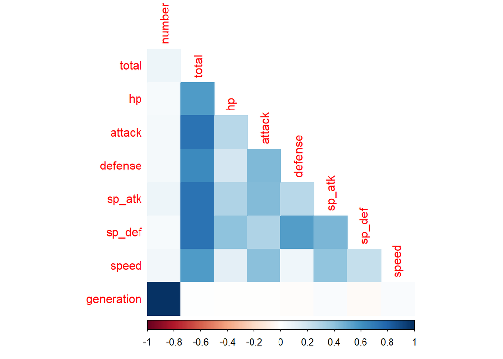

```r
pokem_train %>%
  select(is.numeric) %>%
  cor() %>%
  corrplot(type = 'lower', diag = FALSE,
           method = 'color')
```

I used all the continuous variables into account by using select(is.numeric) but I can not consider number and generation here.

# Exercise 3

```r
tree_spec <- decision_tree() %>%
  set_engine("rpart")

class_tree_spec <- tree_spec %>%
  set_mode("classification")

class_tree_wf <- workflow() %>%
  add_model(class_tree_spec %>% set_args(cost_complexity = tune())) %>%
  add_recipe(pokem_recipe)

param_grid <- grid_regular(cost_complexity(range = c(-3, -1)), levels = 10)

tune_res <- tune_grid(
  class_tree_wf,
  resamples = pokem_folds,
  grid = param_grid,
  metrics = metric_set(roc_auc)
)
```

```
## ! Fold1: preprocessor 1/1: The following variables are not factor vectors and wil...
```

```
## ! Fold2: preprocessor 1/1: The following variables are not factor vectors and wil...
```

```
## ! Fold3: preprocessor 1/1: The following variables are not factor vectors and wil...
```

```
## ! Fold4: preprocessor 1/1: The following variables are not factor vectors and wil...
```

```
## ! Fold5: preprocessor 1/1: The following variables are not factor vectors and wil...
```

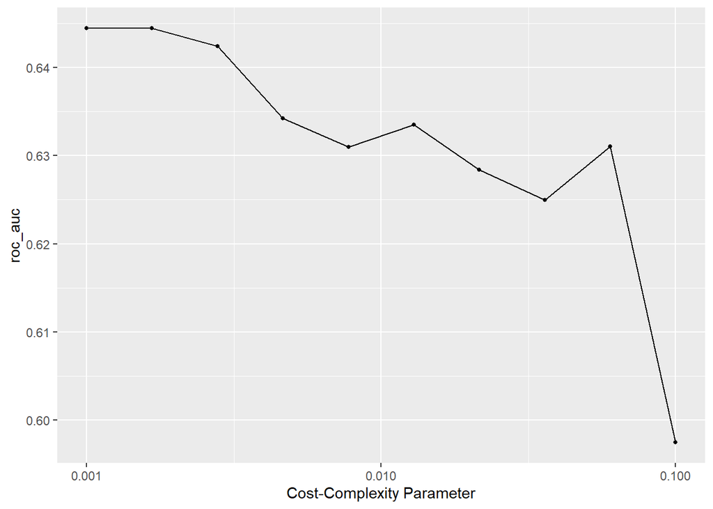

```r
autoplot(tune_res)
```

1. Does a single decision tree perform better with a smaller or larger complexity penalty? A single decision tree perform better with a smaller complexity penalty.Since roc_auc’ increases when complexity when complexity penalty decreases.

# Exercise 4

```r
collect_metrics(tune_res)
```

```
## # A tibble: 10 x 7
##    cost_complexity .metric .estimator  mean     n std_err .config
##              <dbl> <chr>   <chr>      <dbl> <int>   <dbl> <chr>
##  1         0.001   roc_auc hand_till  0.644     5  0.0190 Preprocessor1_Model01
##  2         0.00167 roc_auc hand_till  0.644     5  0.0190 Preprocessor1_Model02
##  3         0.00278 roc_auc hand_till  0.642     5  0.0197 Preprocessor1_Model03
##  4         0.00464 roc_auc hand_till  0.634     5  0.0220 Preprocessor1_Model04
##  5         0.00774 roc_auc hand_till  0.631     5  0.0236 Preprocessor1_Model05
##  6         0.0129  roc_auc hand_till  0.634     5  0.0272 Preprocessor1_Model06
##  7         0.0215  roc_auc hand_till  0.628     5  0.0165 Preprocessor1_Model07
##  8         0.0359  roc_auc hand_till  0.625     5  0.0135 Preprocessor1_Model08
##  9         0.0599  roc_auc hand_till  0.631     5  0.0124 Preprocessor1_Model09
## 10         0.1     roc_auc hand_till  0.597     5  0.0258 Preprocessor1_Model10
```

```r
arrange(tune_res)
```

```
## # Tuning results
## # 5-fold cross-validation using stratification
## # A tibble: 5 x 4
##   splits           id    .metrics          .notes
##   <list>           <chr> <list>            <list>
## 1 <split [289/75]> Fold1 <tibble [10 x 5]> <tibble [1 x 3]>
## 2 <split [291/73]> Fold2 <tibble [10 x 5]> <tibble [1 x 3]>
## 3 <split [291/73]> Fold3 <tibble [10 x 5]> <tibble [1 x 3]>
## 4 <split [292/72]> Fold4 <tibble [10 x 5]> <tibble [1 x 3]>
## 5 <split [293/71]> Fold5 <tibble [10 x 5]> <tibble [1 x 3]>
##
## There were issues with some computations:
##
##   - Warning(s) x5: The following variables are not factor vectors and will be ignore...
##
## Use `collect_notes(object)` for more information.
```

```r
best_complexity <- select_best(tune_res)
best_complexity
```

```
## # A tibble: 1 x 2
##   cost_complexity .config
##             <dbl> <chr>
## 1           0.001 Preprocessor1_Model01
```

# Exercise 5

```r
class_tree_final <- finalize_workflow(class_tree_wf, best_complexity)

class_tree_final_fit <- fit(class_tree_final, data = pokem_train)
```

[figure not shown]

```r
class_tree_final_fit %>%
  extract_fit_engine() %>%
  rpart.plot()
```

# Exercise 5

```r
class_forest_spec <- rand_forest() %>%
  set_engine("ranger", importance = "impurity") %>%
  set_mode("classification")

param_grid2 <- grid_regular(mtry(range = c(1, 8)), trees(range = c(1,8)), min_n(range = c(1,8)),  levels = 8)

forest_workflow <- workflow() %>%
  add_model(class_forest_spec %>% set_args(mtry = tune(), trees = tune(), min_n = tune())) %>%
  add_recipe(pokem_recipe)
```

1. mtry shouldn’t be smaller than 1 or larger than 8. Explain why not mtry should fall between 1 and 8 because there are 8 variables, hence, the maximum for mtry is 8.
2. What type of model would mtry=8 represent? mtry=8 represents the creation of decision tree It should not be smaller than 1 or larger than 8 because the value does not show up correctly

# Exercise 6

```r
tune_res_forest <- tune_grid(
  forest_workflow,
  resamples = pokem_folds,
  grid = param_grid2,
  metrics = metric_set(roc_auc)
)
```

```
## ! Fold1: preprocessor 1/1: The following variables are not factor vectors and wil...
```

```
## ! Fold2: preprocessor 1/1: The following variables are not factor vectors and wil...
```

```
## ! Fold3: preprocessor 1/1: The following variables are not factor vectors and wil...
```

```
## ! Fold4: preprocessor 1/1: The following variables are not factor vectors and wil...
```

```
## ! Fold5: preprocessor 1/1: The following variables are not factor vectors and wil...
```

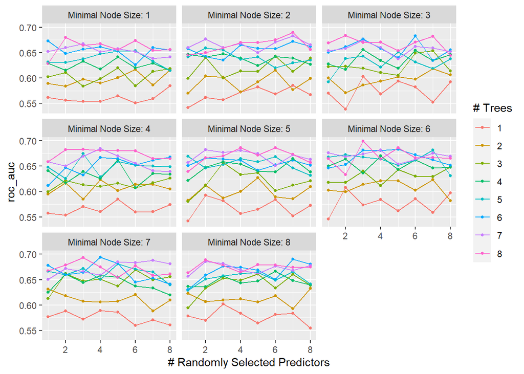

```r
autoplot(tune_res_forest)
```

# Exercise 7

```r
collect_metrics(tune_res_forest)
```

```
## # A tibble: 512 x 9
##     mtry trees min_n .metric .estimator  mean     n std_err .config
##    <int> <int> <int> <chr>   <chr>      <dbl> <int>   <dbl> <chr>
##  1     1     1     1 roc_auc hand_till  0.562     5 0.0181  Preprocessor1_Model~
##  2     2     1     1 roc_auc hand_till  0.556     5 0.0120  Preprocessor1_Model~
##  3     3     1     1 roc_auc hand_till  0.554     5 0.0110  Preprocessor1_Model~
##  4     4     1     1 roc_auc hand_till  0.554     5 0.0184  Preprocessor1_Model~
##  5     5     1     1 roc_auc hand_till  0.565     5 0.00509 Preprocessor1_Model~
##  6     6     1     1 roc_auc hand_till  0.551     5 0.0123  Preprocessor1_Model~
##  7     7     1     1 roc_auc hand_till  0.560     5 0.0184  Preprocessor1_Model~
##  8     8     1     1 roc_auc hand_till  0.584     5 0.00740 Preprocessor1_Model~
##  9     1     2     1 roc_auc hand_till  0.590     5 0.0191  Preprocessor1_Model~
## 10     2     2     1 roc_auc hand_till  0.584     5 0.0114  Preprocessor1_Model~
## # ... with 502 more rows
```

```r
arrange(tune_res_forest)
```

```
## # Tuning results
## # 5-fold cross-validation using stratification
## # A tibble: 5 x 4
##   splits           id    .metrics           .notes
##   <list>           <chr> <list>             <list>
## 1 <split [289/75]> Fold1 <tibble [512 x 7]> <tibble [1 x 3]>
## 2 <split [291/73]> Fold2 <tibble [512 x 7]> <tibble [1 x 3]>
## 3 <split [291/73]> Fold3 <tibble [512 x 7]> <tibble [1 x 3]>
## 4 <split [292/72]> Fold4 <tibble [512 x 7]> <tibble [1 x 3]>
## 5 <split [293/71]> Fold5 <tibble [512 x 7]> <tibble [1 x 3]>
##
## There were issues with some computations:
##
##   - Warning(s) x5: The following variables are not factor vectors and will be ignore...
##
## Use `collect_notes(object)` for more information.
```

```r
best_complexity2 <- select_best(tune_res_forest)
best_complexity2
```

```
## # A tibble: 1 x 4
##    mtry trees min_n .config
##   <int> <int> <int> <chr>
## 1     3     8     6 Preprocessor1_Model379
```

# Exercise 8

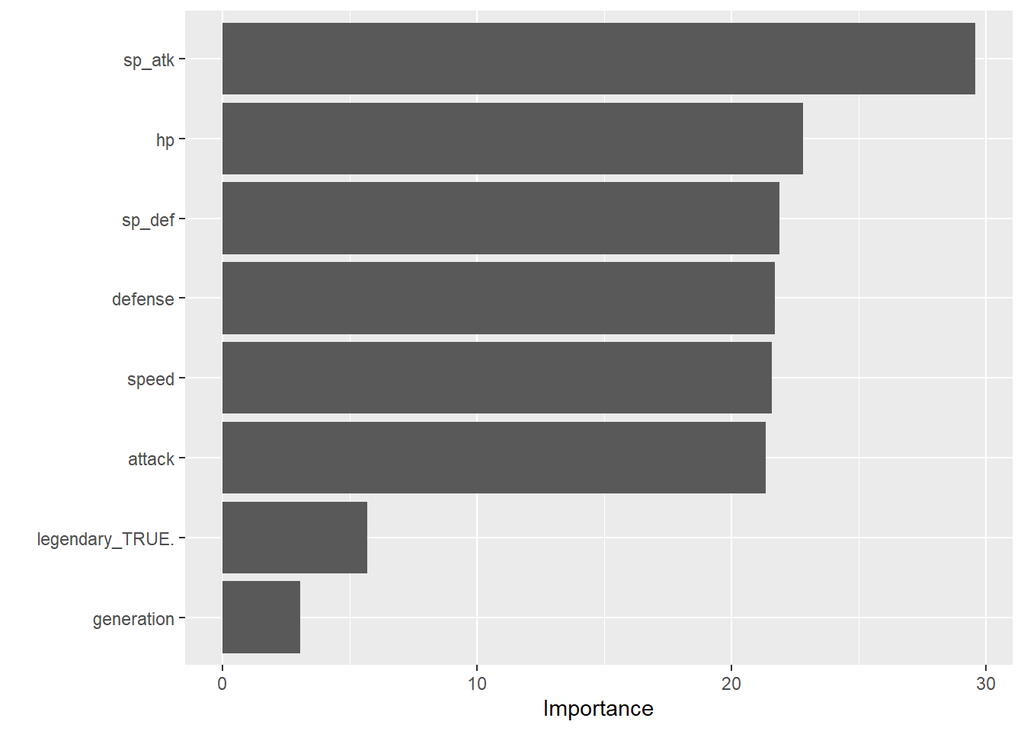

```r
class_tree_final_fit %>%
  pull_workflow_fit() %>%
  vip()
```

# Exercise 9

```r
boost_spec <- boost_tree(trees = c(10,2000), tree_depth = 4) %>%
  set_engine("xgboost") %>%
  set_mode("classification")

param_grid_boost <- grid_regular(trees(range = c(10, 2000)),  levels = 10)

boost_workflow <- workflow() %>%
  add_model(boost_spec %>% set_args(trees = tune())) %>%
  add_recipe(pokem_recipe)

tune_res_boost <- tune_grid(
  boost_workflow,
  resamples = pokem_folds,
  grid = param_grid_boost,
  metrics = metric_set(roc_auc)
)
```

```
## ! Fold1: preprocessor 1/1: The following variables are not factor vectors and wil...
```

```
## ! Fold2: preprocessor 1/1: The following variables are not factor vectors and wil...
```

```
## ! Fold3: preprocessor 1/1: The following variables are not factor vectors and wil...
```

```
## ! Fold4: preprocessor 1/1: The following variables are not factor vectors and wil...
```

```
## ! Fold5: preprocessor 1/1: The following variables are not factor vectors and wil...
```

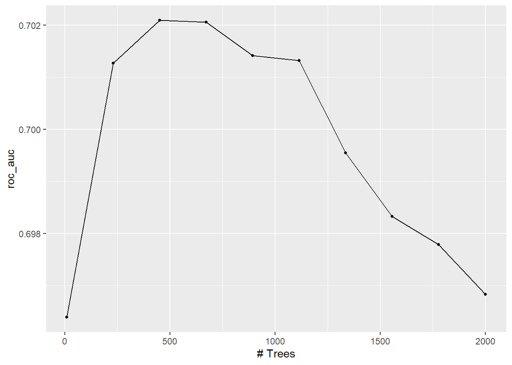

```r
autoplot(tune_res_boost)
```

```r
collect_metrics(tune_res_boost)
```

```
## # A tibble: 10 x 7
##    trees .metric .estimator  mean     n std_err .config
##    <int> <chr>   <chr>      <dbl> <int>   <dbl> <chr>
##  1    10 roc_auc hand_till  0.696     5 0.0105  Preprocessor1_Model01
##  2   231 roc_auc hand_till  0.701     5 0.00851 Preprocessor1_Model02
##  3   452 roc_auc hand_till  0.702     5 0.00787 Preprocessor1_Model03
##  4   673 roc_auc hand_till  0.702     5 0.00800 Preprocessor1_Model04
##  5   894 roc_auc hand_till  0.701     5 0.00812 Preprocessor1_Model05
##  6  1115 roc_auc hand_till  0.701     5 0.00849 Preprocessor1_Model06
##  7  1336 roc_auc hand_till  0.700     5 0.00853 Preprocessor1_Model07
##  8  1557 roc_auc hand_till  0.698     5 0.00838 Preprocessor1_Model08
##  9  1778 roc_auc hand_till  0.698     5 0.00825 Preprocessor1_Model09
## 10  2000 roc_auc hand_till  0.697     5 0.00819 Preprocessor1_Model10
```

```r
arrange(tune_res_boost)
```

```
## # Tuning results
## # 5-fold cross-validation using stratification
## # A tibble: 5 x 4
##   splits           id    .metrics          .notes
##   <list>           <chr> <list>            <list>
## 1 <split [289/75]> Fold1 <tibble [10 x 5]> <tibble [1 x 3]>
## 2 <split [291/73]> Fold2 <tibble [10 x 5]> <tibble [1 x 3]>
## 3 <split [291/73]> Fold3 <tibble [10 x 5]> <tibble [1 x 3]>
## 4 <split [292/72]> Fold4 <tibble [10 x 5]> <tibble [1 x 3]>
## 5 <split [293/71]> Fold5 <tibble [10 x 5]> <tibble [1 x 3]>
##
## There were issues with some computations:
##
##   - Warning(s) x5: The following variables are not factor vectors and will be ignore...
##
## Use `collect_notes(object)` for more information.
```

```r
best_complexity3 <- select_best(tune_res_boost)
best_complexity3
```

```
## # A tibble: 1 x 2
##   trees .config
##   <int> <chr>
## 1   452 Preprocessor1_Model03
```